# Validación pronóstica de un score transcriptómico de proliferación en adenocarcinoma de pulmón (TCGA-LUAD) con replicación externa GEO

Autor/a

Juan Sebastián Díaz Tobar

Fecha de publicación

18 de julio de 2026

# 1 Resumen

**Objetivo.** Evaluar si un score transcriptómico de proliferación (firmas Hallmark G2M y E2F, cuantificadas con singscore) aporta información pronóstica más allá del estadio, la edad y el sexo en adenocarcinoma de pulmón (LUAD), y si replica en una cohorte independiente.

**Métodos.** TCGA-LUAD (n=504; 182 muertes) se particionó en training/test antes de todo análisis; toda selección se realizó solo en training. Se ajustaron modelos de Cox clínico (edad, sexo, estadio) frente a clínico + score, con verificación de supuestos, validación interna (C-index corregido por optimismo, AUC(t), Brier/IPA con contrastes formales entre modelos anidados) y validación externa en GSE68465 (n=442; 236 muertes), tanto por transporte del modelo congelado como por re-ajuste dentro de la cohorte.

**Resultados.** El score se asoció de forma independiente a la supervivencia tras ajuste (HR 1.35; IC95% 1.11–1.63; razón de verosimilitud p=0.003) y la asociación replicó externamente (HR ajustado 1.24; IC95% 1.08–1.42; p=0.002). Sin embargo, su aporte incremental de discriminación no fue estadísticamente detectable: el C-index corregido subió de 0.66 a 0.69, pero los contrastes de ΔAUC y ΔBrier en el test retenido no fueron significativos (IC cruzan cero). Un modelo data-driven (elastic-net, 26 genes) sobreajustó gravemente (C aparente 0.77 → 0.56 en test, IC incluye 0.5) y no superó al score simple. En transporte congelado el score empeoró la calibración (ΔBrier>0; p<0.05 en los tres horizontes); una descomposición algebraica mostró que se debe a una descalibración corregible (la media del score en escala TCGA se desplaza −3.18 DE en GEO, infra-estimando el riesgo ~61%), que se resuelve re-estandarizando el score en la cohorte destino.

**Conclusiones.** El score de proliferación es una señal pronóstica real y replicable pero de aporte incremental pequeño sobre el estadio; la complejidad data-driven no mejora el desempeño y el uso entre plataformas exige recalibración. El valor del trabajo reside en la validación rigurosa, no en la novedad de la firma.

# 2 Objetivo

**Pregunta.** ¿Un *score* transcriptómico de proliferación (firmas Hallmark G2M y E2F, cuantificadas con *singscore*) aporta información pronóstica **más allá** de las variables clínicas estándar (estadio, edad, sexo) en adenocarcinoma de pulmón, y **replica** en una cohorte GEO independiente?

**Hipótesis.**

- **H1**: el score se asocia de forma independiente a la supervivencia tras ajuste y mejora el C-index frente al modelo clínico, replicando externamente.
- **H0**: no aporta tras ajuste, o no replica.

> Resultado *esperado y aceptable*: un aporte incremental **pequeño** y una **atenuación** de la señal en validación externa. Este estudio está diseñado para poder **rechazar** H1 con honestidad si los datos no la sostienen.

# 3 Métodos

**Datos.** TCGA-LUAD RNA-seq (STAR counts) y clínica vía `TCGAbiolinks` (open-access). Endpoint pronóstico tomado del recurso curado **TCGA-CDR** (Liu et al., *Cell* 2018): supervivencia global (OS) o intervalo libre de progresión (PFI), **no** `days_to_death` crudo. Validación externa: cohorte GEO de LUAD con supervivencia (GSE68465) vía `GEOquery`.

**Prevención de fuga de información.** La cohorte TCGA se **particiona en training/test antes de cualquier análisis** (estratificando por estadio). Toda selección —filtro de genes, escala del score, ajuste del elastic-net— se hace **solo en training**; el test permanece intacto para validación interna.

**Preprocesamiento.** Filtro de genes de baja expresión aprendido en training; estabilización de varianza (VST de `DESeq2`, con la tendencia de dispersión ajustada en training) o logCPM; QC de muestras por tamaño de librería; inspección de efecto de lote (TSS/placa) por PCA (se documenta, no se sobre-corrige).

**Score y features.** *(a)* Primario: proliferación con `singscore` (rank-based, transferible entre plataformas) sobre Hallmark G2M/E2F. *(b)* Secundario: Cox elastic-net (`glmnet`), λ por validación cruzada.

**Modelado.** Cox de riesgos proporcionales comparando **modelo clínico** (edad, sexo, estadio) frente a **clínico + score**. Se verifican supuestos: proporcionalidad (Schoenfeld), forma funcional (residuos de martingala) e influencia (dfbeta). Si falla la proporcionalidad, se reporta y se evalúan alternativas (estratificado, RMST, RSF) como sensibilidad.

**Validación interna.** C-index corregido por optimismo vía bootstrap; AUC tiempo-dependiente (`timeROC`); calibración y Brier/IPA (`riskRegression`), con intervalos de confianza.

**Validación externa.** Transporte del modelo congelado a GEO (discriminación y calibración) y, por separado, re-ajuste dentro de GEO para comprobar si la asociación independiente replica.

**Reproducibilidad.** Semilla global en `config/params.yml`, entorno `renv`, pipeline `targets`, tests `testthat`, y `sessionInfo()` al final.

# 4 Resultados

## 4.1 Descripción de la cohorte y partición

Resumen de cohorte TCGA-LUAD

| variable | valor |
| --- | --- |
| N muestras | 504 |
| Eventos (n, %) | 182 (36.1%) |
| Edad (mediana [IQR]) | 66 [59-73] |
| Mujeres (n, %) | 272 (54.0%) |
| Estadio I/II/III/IV | 270 / 120 / 81 / 25 |
| Estadio faltante (n) | 8 |
| Seguimiento mediano (dias, KM inverso) | 882 |
| Endpoint | OS |

Balance de estadio entre training y test

| stratum | test | train |
| --- | --- | --- |
| I | 81 | 189 |
| II | 36 | 84 |
| III | 25 | 56 |
| IV | 8 | 17 |
| NA | 3 | 5 |

## 4.2 Control de calidad

Muestras con mayor desviación de tamaño de librería (top 8)

|  | sample_id | library_size | log10_libsize | mad_z | outlier |
| --- | --- | --- | --- | --- | --- |
| TCGA-62-A470-01A-11R-A24H-07 | TCGA-62-A470-01A-11R-A24H-07 | 18001906 | 7.255 | -2.055 | FALSE |
| TCGA-62-8397-01A-11R-2326-07 | TCGA-62-8397-01A-11R-2326-07 | 18571641 | 7.269 | -1.985 | FALSE |
| TCGA-50-5930-01A-11R-1755-07 | TCGA-50-5930-01A-11R-1755-07 | 19143672 | 7.282 | -1.918 | FALSE |
| TCGA-38-4626-01A-01R-1206-07 | TCGA-38-4626-01A-01R-1206-07 | 103673396 | 8.016 | 1.837 | FALSE |
| TCGA-73-4659-01A-01R-1206-07 | TCGA-73-4659-01A-01R-1206-07 | 103639275 | 8.016 | 1.836 | FALSE |
| TCGA-NJ-A4YP-01A-11R-A262-07 | TCGA-NJ-A4YP-01A-11R-A262-07 | 101532163 | 8.007 | 1.791 | FALSE |
| TCGA-05-4398-01A-01R-1206-07 | TCGA-05-4398-01A-01R-1206-07 | 101235803 | 8.005 | 1.784 | FALSE |
| TCGA-NJ-A55R-01A-11R-A262-07 | TCGA-NJ-A55R-01A-11R-A262-07 | 99398911 | 7.997 | 1.743 | FALSE |

Asociación PC ~ variable de lote (R²): magnitud del efecto de lote

| batch | pc | r2 |
| --- | --- | --- |
| tss | PC1 | 0.106 |
| tss | PC2 | 0.063 |
| tss | PC3 | 0.159 |
| tss | PC4 | 0.070 |
| tss | PC5 | 0.052 |
| plate | PC1 | 0.059 |
| plate | PC2 | 0.042 |
| plate | PC3 | 0.069 |
| plate | PC4 | 0.050 |
| plate | PC5 | 0.047 |

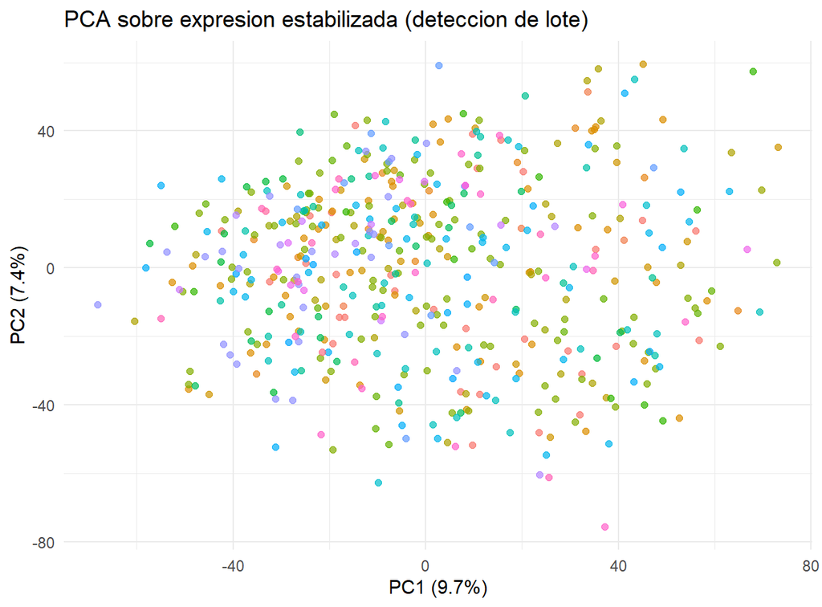

Figura 1: PCA de la expresión estabilizada por varianza (VST), coloreada por centro de tejido (TSS). Las dos primeras componentes explican poca varianza (PC1 9.7%, PC2 7.4%) y las muestras se mezclan sin agruparse por lote, consistente con el R² bajo de cada PC frente a TSS/placa (máximo 0.159). El efecto de lote se documenta pero no se corrige, para no eliminar señal biológica confundida con el centro. La leyenda se omite: TSS tiene 33 niveles.

## 4.3 Exploración de supervivencia

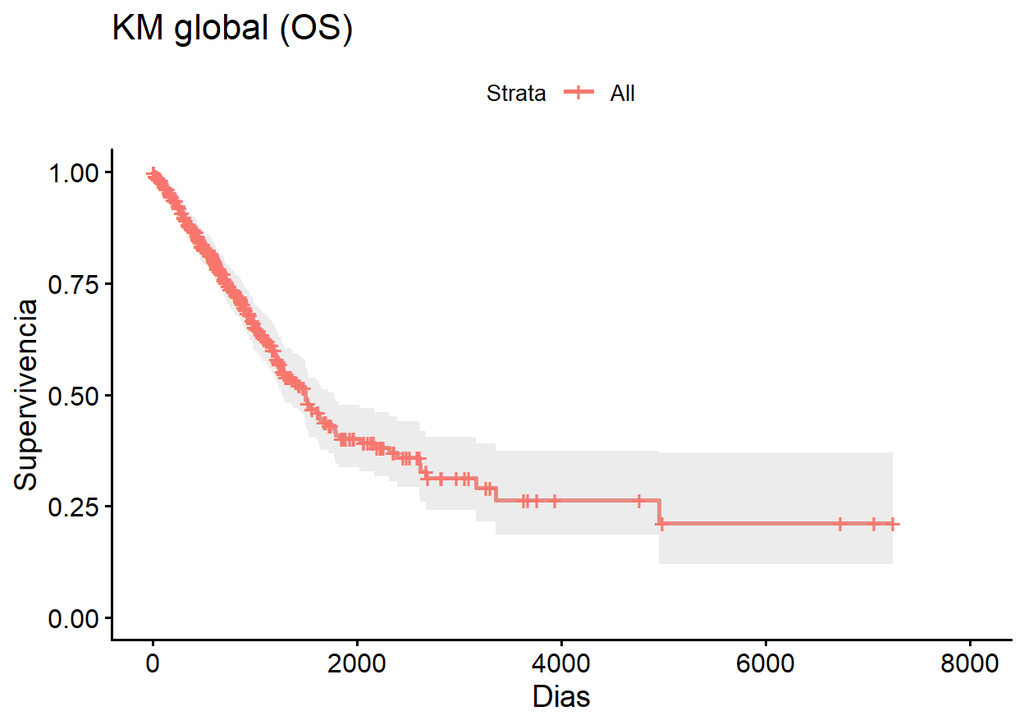

Figura 2: Supervivencia global en TCGA-LUAD (Kaplan-Meier). OS de la cohorte completa (n=504, 182 eventos); banda sombreada = IC95%. La mediana de supervivencia es de 1499 días (IC95% 1268–1778), distinta de la mediana de SEGUIMIENTO (882 d por KM inverso, ver tabla de cohorte). Los eventos se vuelven escasos más allá de ~3500 días, donde la curva se estabiliza en torno al 21%.

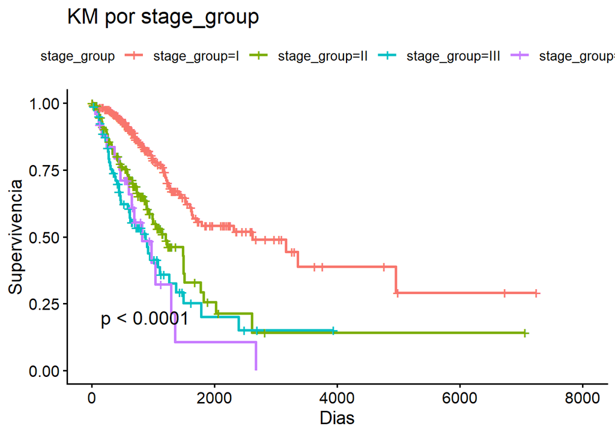

Figura 3: Supervivencia global por estadio AJCC agrupado. El estadio discrimina fuertemente el pronóstico (log-rank p=1.2e-12): estadio I mejor, IV peor. Los estadios II y III se solapan parcialmente y la curva de IV (n=25) es inestable y termina temprano por el bajo número de sujetos. Esta señal dominante del estadio motiva ajustarlo en todos los modelos: sin ese ajuste, un marcador tiende a ser su proxy.

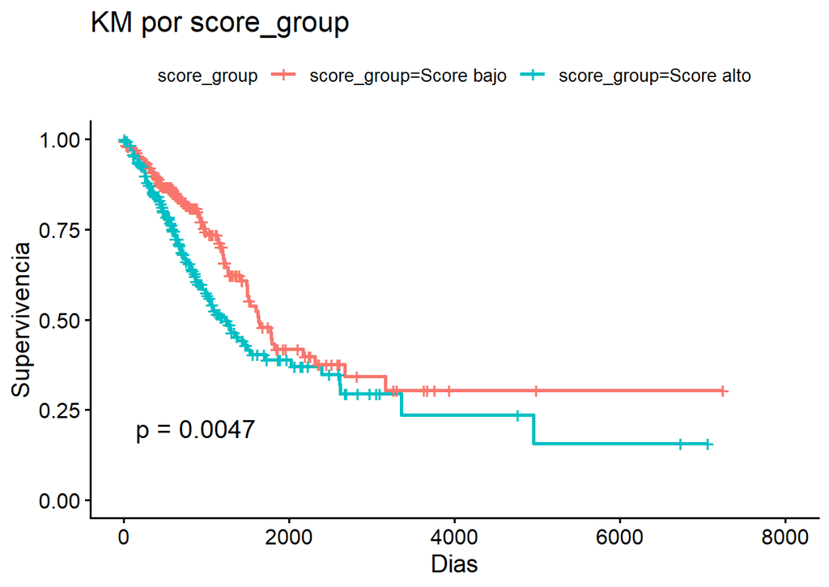

Figura 4: Supervivencia global por grupo alto/bajo del score de proliferación (corte en la mediana; el modelado usa el score continuo). La separación es real pero modesta (log-rank p=0.005), muy inferior a la del estadio (Figura 3). Dicotomizar por la mediana pierde información y se muestra solo con fines descriptivos.

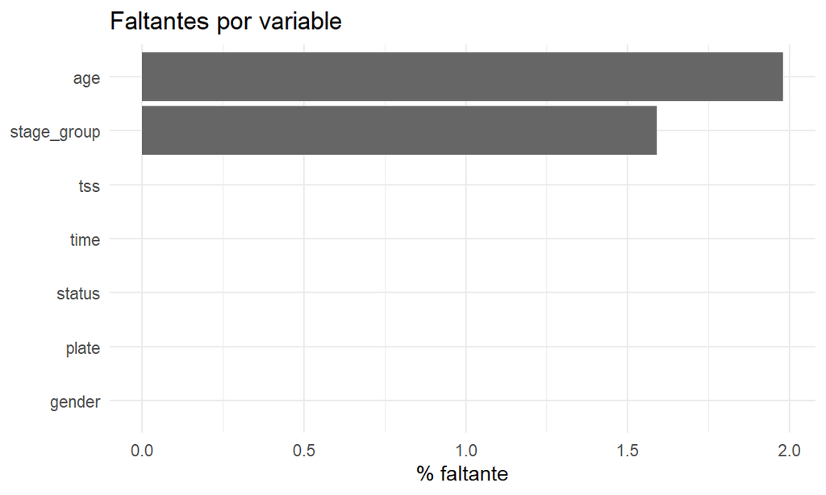

Figura 5: Datos faltantes por variable. Ausencia mínima: edad 1.98% y estadio 1.59% (8/504); el resto sin faltantes. Respalda el análisis primario por caso completo, cuyo HR del score es prácticamente idéntico al de imputación múltiple (1.346 vs 1.325).

## 4.4 Modelo incremental (clínico vs clínico + score)

Modelo clínico (HR, IC95%)

| term | HR | lower | upper | p |
| --- | --- | --- | --- | --- |
| age_std | 1.067 | 0.882 | 1.289 | 0.506 |
| gendermale | 1.115 | 0.769 | 1.618 | 0.565 |
| stage_groupII | 2.614 | 1.652 | 4.135 | 0.000 |
| stage_groupIII | 3.377 | 2.096 | 5.442 | 0.000 |
| stage_groupIV | 3.354 | 1.655 | 6.798 | 0.001 |

Modelo clínico + score de proliferación

| term | HR | lower | upper | p |
| --- | --- | --- | --- | --- |
| age_std | 1.152 | 0.945 | 1.403 | 0.162 |
| gendermale | 1.090 | 0.753 | 1.579 | 0.648 |
| stage_groupII | 2.455 | 1.547 | 3.895 | 0.000 |
| stage_groupIII | 3.179 | 1.969 | 5.133 | 0.000 |
| stage_groupIV | 3.001 | 1.470 | 6.125 | 0.003 |
| prolif_score | 1.346 | 1.108 | 1.634 | 0.003 |

Test de razón de verosimilitud (aporte incremental del score)

| loglik | Chisq | Df | Pr(>\|Chi\|) |
| --- | --- | --- | --- |
| -556.555 | NA | NA | NA |
| -552.005 | 9.102 | 1 | 0.003 |

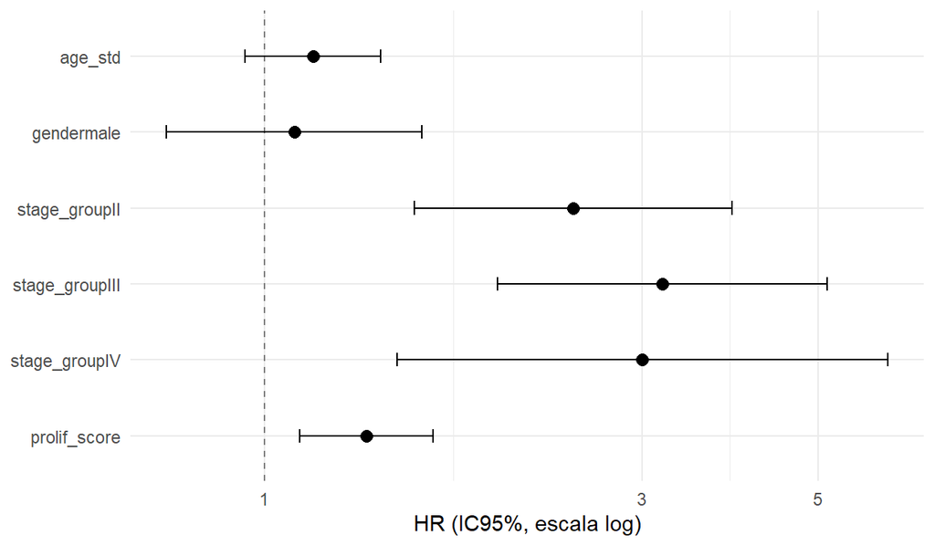

Figura 6: Hazard ratios del modelo clínico + score (IC95%, escala logarítmica; línea discontinua en HR=1). El estadio domina el pronóstico (HR ~2.5–3.2 para II–IV frente a I), mientras el score aporta un efecto pequeño pero claramente separado de 1 (HR 1.35 por DE). Edad y sexo no alcanzan significación tras el ajuste.

> **Lectura crítica.** El HR del score debe interpretarse **tras** el ajuste por estadio. Un score que solo es significativo sin ajuste es, muy probablemente, un proxy del estadio.

### 4.4.1 Supuestos del modelo

Prueba de Schoenfeld (proporcionalidad de riesgos). p pequeño = posible violación

|  | term | chisq | df | p |
| --- | --- | --- | --- | --- |
| age_std | age_std | 1.727 | 1 | 0.189 |
| gender | gender | 2.582 | 1 | 0.108 |
| stage_group | stage_group | 6.259 | 3 | 0.100 |
| prolif_score | prolif_score | 1.178 | 1 | 0.278 |
| GLOBAL | GLOBAL | 12.482 | 6 | 0.052 |

## 4.5 Validación interna

C-index aparente y corregido por optimismo (bootstrap)

|  | c_apparent | c_optimism_corrected | optimism |
| --- | --- | --- | --- |
| Clinico | 0.679 | 0.663 | 0.016 |
| Clinico+Score | 0.703 | 0.687 | 0.015 |

C-index en el test interno retenido

| modelo | C | lower | upper | se |
| --- | --- | --- | --- | --- |
| Clinico | 0.634 | 0.554 | 0.713 | 0.041 |
| Clinico+Score | 0.668 | 0.588 | 0.748 | 0.041 |

Brier / IPA (test)

| model | times | IPA | Brier | se | lower | upper |
| --- | --- | --- | --- | --- | --- | --- |
| Null model | 365 | 0.000 | 0.112 | 0.021 | 0.070 | 0.153 |
| Null model | 1095 | 0.000 | 0.242 | 0.009 | 0.224 | 0.260 |
| Null model | 1825 | 0.000 | 0.182 | 0.032 | 0.120 | 0.245 |
| Clinico | 365 | 0.039 | 0.107 | 0.020 | 0.068 | 0.147 |
| Clinico | 1095 | 0.111 | 0.215 | 0.020 | 0.176 | 0.255 |
| Clinico | 1825 | -0.213 | 0.221 | 0.022 | 0.179 | 0.264 |
| Clinico+Score | 365 | 0.054 | 0.106 | 0.020 | 0.067 | 0.144 |
| Clinico+Score | 1095 | 0.119 | 0.213 | 0.021 | 0.173 | 0.254 |
| Clinico+Score | 1825 | -0.256 | 0.229 | 0.024 | 0.181 | 0.277 |

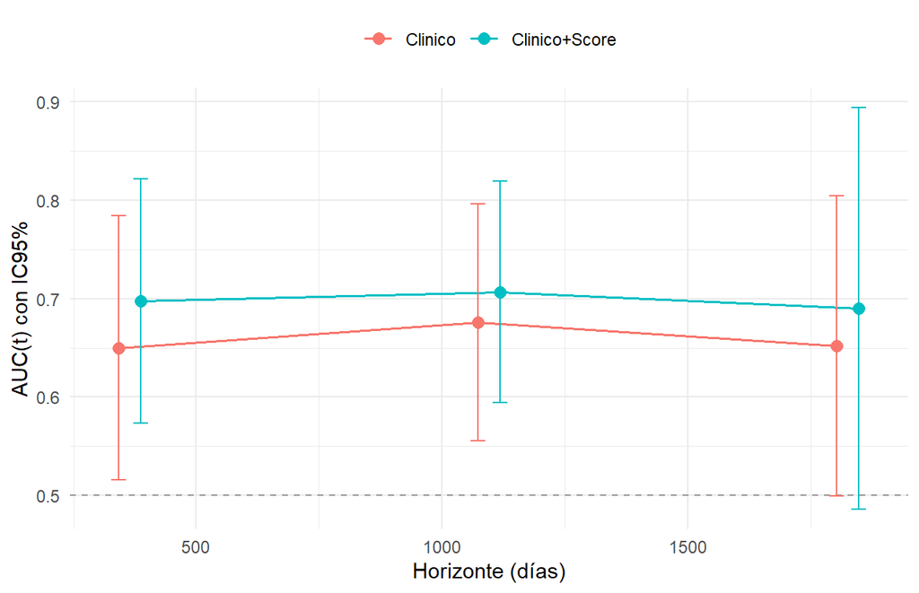

Figura 7: AUC tiempo-dependiente en el test interno retenido, con IC95%, a 1, 3 y 5 años. El modelo con score queda por encima del clínico en los tres horizontes, pero los intervalos se solapan ampliamente y los contrastes formales de ΔAUC no son significativos (ver tabla de contrastes).

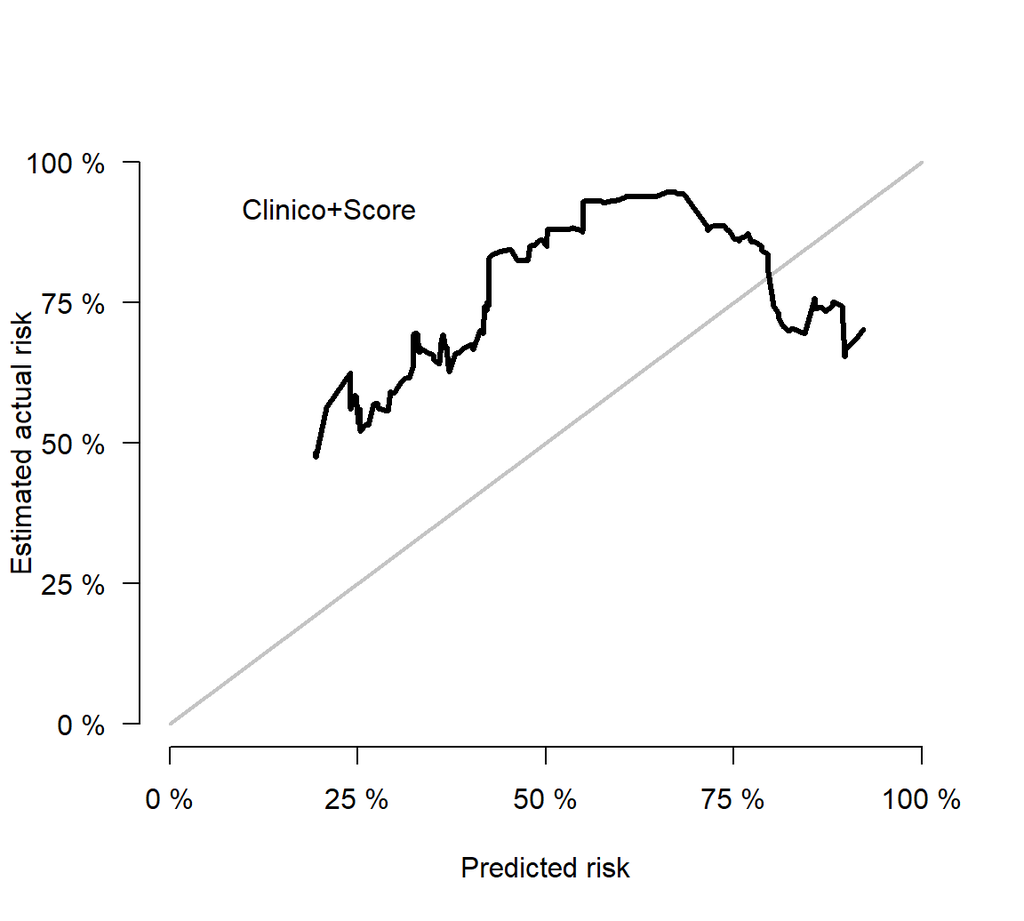

### 4.5.1 Contrastes formales entre modelos anidados (test interno)

Δ AUC (clínico+score − clínico), IC95% y p

| Horizonte (d) | Delta AUC (score - clinico) | IC95% inf | IC95% sup | p |
| --- | --- | --- | --- | --- |
| 365 | 0.048 | -0.021 | 0.116 | 0.171 |
| 1095 | 0.031 | -0.044 | 0.105 | 0.418 |
| 1825 | 0.038 | -0.105 | 0.181 | 0.603 |

Δ Brier (clínico+score − clínico); Δ<0 favorece al score

| Horizonte (d) | Delta Brier (score - clinico) | IC95% inf | IC95% sup | p |
| --- | --- | --- | --- | --- |
| 365 | -0.002 | -0.006 | 0.002 | 0.399 |
| 1095 | -0.002 | -0.019 | 0.015 | 0.814 |
| 1825 | 0.008 | -0.015 | 0.031 | 0.505 |

> **Conclusión formal (interno):** todos los IC de Δ AUC y Δ Brier cruzan el cero y todos los p > 0.05 — el score **no añade discriminación ni precisión de forma detectable** en el test interno. Con 153 muestras y 65 eventos, este contraste tiene poca potencia.

## 4.6 Score data-driven (elastic-net) frente al score simple

Elastic-net Cox (ajustado solo en training)

| Metrica | Valor |
| --- | --- |
| Genes seleccionados | 26 |
| lambda.min | 0.1695 |
| C train aparente | 0.774 |
| C train ‘corregido’ | 0.7761 |
| C test interno | 0.5637 |
| C GEO congelado | 0.5986 |
| Genes disponibles en GEO | 15/26 |

> **El modelo sofisticado NO supera al score simple.** El elastic-net parece excelente en training (C≈0.77) pero **colapsa en el test interno (C≈0.56, IC incluye 0.5)**, por debajo del modelo clínico (0.63) y de clínico+score (0.67). La brecha aparente→test (~0.21) es sobreajuste de manual.

> **Aviso metodológico:** el “C corregido” del elastic-net es engañoso — `rms::validate` re-ajusta el Cox sobre un predictor **ya seleccionado**, sin repetir la selección de genes dentro de cada bootstrap, así que no captura el optimismo de la selección. Una corrección honesta exigiría envolver toda la selección en el bootstrap.

## 4.7 Análisis de sensibilidad

Schoenfeld bajo estratificación

|  | Termino | chisq | df | p |
| --- | --- | --- | --- | --- |
| age_std | age_std | 1.443 | 1 | 0.230 |
| gender | gender | 2.059 | 1 | 0.151 |
| prolif_score | prolif_score | 1.167 | 1 | 0.280 |
| GLOBAL | GLOBAL | 5.141 | 3 | 0.162 |

RMST por grupo alto/bajo de score (robusto a no proporcionalidad)

|  | grupo | records | n.max | n.start | events | rmean | se(rmean) | median | 0.95LCL | 0.95UCL |
| --- | --- | --- | --- | --- | --- | --- | --- | --- | --- | --- |
| score_group=score_alto | score_group=score_alto | 170 | 170 | 170 | 70 | 1152.110 | 59.071 | 1229 | 864 | 2617 |
| score_group=score_bajo | score_group=score_bajo | 170 | 170 | 170 | 46 | 1397.027 | 55.490 | 1798 | 1268 | NA |

Cox completo con imputación múltiple (mice) — sensibilidad a faltantes

| term | estimate | std.error | statistic | df | p.value | 2.5 % | 97.5 % | conf.low | conf.high |
| --- | --- | --- | --- | --- | --- | --- | --- | --- | --- |
| age_std | 0.146 | 0.101 | 1.441 | 108.375 | 0.152 | -0.055 | 0.346 | -0.055 | 0.346 |
| gendermale | 0.065 | 0.189 | 0.343 | 107.997 | 0.732 | -0.310 | 0.439 | -0.310 | 0.439 |
| stage_groupII | 0.987 | 0.237 | 4.167 | 107.760 | 0.000 | 0.517 | 1.456 | 0.517 | 1.456 |
| stage_groupIII | 1.233 | 0.245 | 5.032 | 105.757 | 0.000 | 0.747 | 1.719 | 0.747 | 1.719 |
| stage_groupIV | 1.179 | 0.370 | 3.187 | 103.806 | 0.002 | 0.445 | 1.912 | 0.445 | 1.912 |
| prolif_score | 0.281 | 0.098 | 2.874 | 108.585 | 0.005 | 0.087 | 0.475 | 0.087 | 0.475 |

> **Sin divergencias que indiquen fragilidad.** El HR del score es estable al estratificar por estadio (≈1.34 vs 1.35) y con imputación múltiple (≈1.33 vs 1.35), y el global de Schoenfeld deja de ser limítrofe al estratificar. Los C-index del modelo estratificado (~0.53–0.59) **no** son comparables con los de la validación interna: el predictor lineal estratificado excluye el efecto del estadio y mide solo discriminación dentro de cada estrato.

## 4.8 Validación externa (GEO)

Discriminación en GEO (C-index): score solo y modelo TCGA congelado

|  | C | lower | upper | se |
| --- | --- | --- | --- | --- |
| Score solo (C) | 0.610 | 0.573 | 0.648 | 0.019 |
| Modelo congelado (C) | 0.708 | 0.675 | 0.741 | 0.017 |

Re-ajuste DENTRO de GEO (n=439, eventos=235; ajustado por: age_std, gender, stage_group): ¿replica la asociación independiente?

| term | HR | lower | upper | p |
| --- | --- | --- | --- | --- |
| age_std | 1.346 | 1.173 | 1.545 | 0.000 |
| gendermale | 1.259 | 0.968 | 1.636 | 0.086 |
| stage_groupII | 2.288 | 1.678 | 3.121 | 0.000 |
| stage_groupIII | 4.467 | 3.237 | 6.165 | 0.000 |
| stage_groupIV | NA | NA | NA | NA |
| prolif_score | 1.240 | 1.082 | 1.421 | 0.002 |

Brier / IPA del modelo congelado en GEO (calibración/precisión transportada)

| model | times | IPA | Brier | se | lower | upper |
| --- | --- | --- | --- | --- | --- | --- |
| Null model | 365 | 0.000 | 0.098 | 0.012 | 0.075 | 0.120 |
| Null model | 1095 | 0.000 | 0.218 | 0.008 | 0.202 | 0.234 |
| Null model | 1825 | 0.000 | 0.248 | 0.002 | 0.243 | 0.252 |
| Clinico | 365 | 0.076 | 0.090 | 0.010 | 0.069 | 0.111 |
| Clinico | 1095 | 0.174 | 0.180 | 0.008 | 0.164 | 0.196 |
| Clinico | 1825 | 0.139 | 0.213 | 0.009 | 0.196 | 0.230 |
| Clinico+Score | 365 | 0.021 | 0.095 | 0.013 | 0.071 | 0.120 |
| Clinico+Score | 1095 | 0.043 | 0.209 | 0.014 | 0.181 | 0.236 |
| Clinico+Score | 1825 | 0.020 | 0.243 | 0.013 | 0.217 | 0.268 |

### 4.8.1 Contrastes formales dentro de GEO

Δ AUC (clínico+score − clínico) en GEO

| Horizonte (d) | Delta AUC (score - clinico) | IC95% inf | IC95% sup | p |
| --- | --- | --- | --- | --- |
| 365 | 0.041 | 0.002 | 0.079 | 0.038 |
| 1095 | 0.019 | -0.014 | 0.051 | 0.253 |
| 1825 | 0.013 | -0.021 | 0.048 | 0.448 |

Δ Brier en GEO; Δ>0 significa que el score EMPEORA la precisión

| Horizonte (d) | Delta Brier (score - clinico) | IC95% inf | IC95% sup | p |
| --- | --- | --- | --- | --- |
| 365 | 0.005 | 0.000 | 0.010 | 0.036 |
| 1095 | 0.029 | 0.011 | 0.046 | 0.001 |
| 1825 | 0.029 | 0.005 | 0.054 | 0.017 |

### 4.8.2 Experimento: ¿la descalibración externa es por la ESCALA del score?

Se aplica el mismo modelo congelado a GEO en dos versiones que difieren *solo* en cómo se estandariza `prolif_score` (edad, sexo y estadio idénticos): **(a)** z-score con media/DE del training de TCGA, **(b)** z-score con media/DE de la propia cohorte GEO.

IPA/Brier en GEO: clínico vs score con escala TCGA (a) vs escala GEO (b)

| times | IPA_clinico | Brier_clinico | IPA_a_TCGA | Brier_a_TCGA | IPA_b_GEO | Brier_b_GEO |
| --- | --- | --- | --- | --- | --- | --- |
| 365 | 0.076 | 0.090 | 0.021 | 0.095 | 0.102 | 0.088 |
| 1095 | 0.174 | 0.180 | 0.043 | 0.209 | 0.214 | 0.171 |
| 1825 | 0.139 | 0.213 | 0.020 | 0.243 | 0.173 | 0.205 |

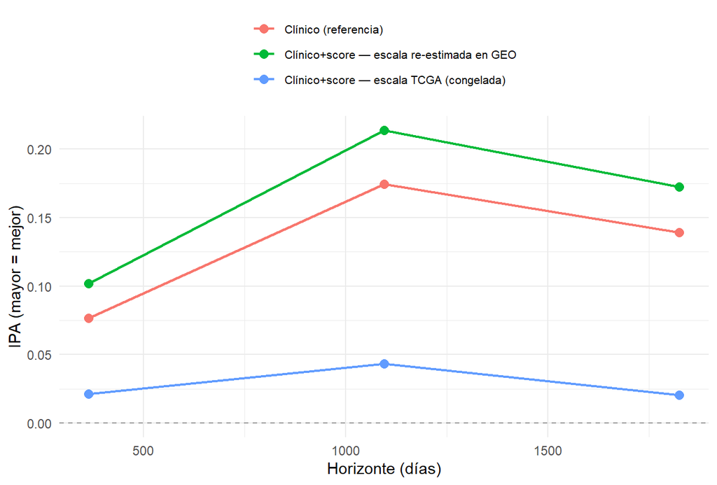

Figura 9: Recalibración del transporte a GEO. IPA (mayor es mejor) del modelo clínico frente al clínico+score con la escala del score congelada de TCGA y con la escala re-estimada dentro de GEO. Con la escala congelada el score queda por DEBAJO del modelo clínico en los tres horizontes; al re-estandarizarlo en la cohorte destino pasa por ENCIMA. Es la figura que resume el hallazgo principal sobre transportabilidad: la señal es real, pero la estandarización no viaja.

Re-estandarizar el score dentro de GEO restaura la calibración y la lleva **por encima** del modelo clínico (IPA 0.10/0.21/0.17 frente a 0.08/0.17/0.14 del clínico), partiendo de 0.02/0.04/0.02 con la escala de TCGA.

**Qué recalibra exactamente.** La lectura **no** es “escala del score *en lugar de* hazard basal”: el re-escalado recalibra **dos cosas a la vez**. Con $z_T=(r-\mu_T)/\sigma_T$ y $z_G=(r-\mu_G)/\sigma_G$:

$$\beta z_T \;=\; \underbrace{\beta\frac{\sigma_G}{\sigma_T}}_{\text{pendiente}} z_G \;+\; \underbrace{\beta\frac{\mu_G-\mu_T}{\sigma_T}}_{\text{constante para todos los sujetos}}$$

El componente de **media** desplaza el predictor lineal de *todos* los sujetos en una constante — eso es **calibración-en-lo-grande**, es decir recalibración del **basal/intercepto**. El de **DE** ajusta la **pendiente** del término del score.

Descomposición del re-escalado: componente de media (basal) y de DE (pendiente)

| Componente | Valor | Debería ser |
| --- | --- | --- |
| Media del score en GEO (escala TCGA) | -3.179 | ~0 |
| → desplazamiento constante del lp | -0.944 | 0 |
| → factor multiplicativo del riesgo | 0.389 | 1 |
| DE del score en GEO (escala TCGA) | 1.219 | ~1 |
| → pendiente efectiva | 0.362 | = β |
| β original (por DE de TCGA) | 0.297 | — |

> **Conclusión corregida.** La descalibración externa es un problema de **recalibración con ambos ingredientes**, y el dominante es el del **basal**: en escala TCGA el score de GEO tiene media z ≈ −3.2 (en vez de ~0), lo que desplaza el predictor lineal de todos los sujetos y multiplica el riesgo predicho por ≈0.39 (infra-estimación sistemática de ~61%). A la vez la DE (≈1.22 en vez de ~1) infla la pendiente efectiva un ~22%. Re-estandarizar el score en la cohorte destino corrige **los dos simultáneamente**.

> **Implicación práctica (intacta):** el score es transportable **en rango** —el orden de riesgo se conserva, por eso la discriminación aguanta— pero **su estandarización debe re-estimarse en cada cohorte**; no debe usarse congelado el z-score de TCGA.

> **Lectura crítica.** La discriminación es invariante a re-escalados monótonos del score (por eso se transfiere), pero la **calibración** no lo es. Además, la comparación *interno → externo* del IPA **no es una inferencia válida**: el IPA interno a 5 años es negativo por inestabilidad de muestra pequeña (153 muestras, 65 eventos, muy pocos en riesgo a ese horizonte), no porque el modelo mejore al salir a GEO. La señal fiable sobre calibración es la comparación **dentro** de GEO, entre modelos anidados sobre los mismos sujetos.

# 5 Discusión — amenazas a la validez

- **Potencia: el estudio mide asociación, no incremento de discriminación.** Con 504 muestras y 182 eventos (153/65 en el test interno), el diseño está potenciado para detectar la **asociación** del score con la supervivencia (HR 1.35, p=0.003), pero **no** para estimar con precisión el **incremento de discriminación**: ΔC ≈ 0.01–0.03 con intervalos que se solapan y contrastes de Δ AUC / Δ Brier no significativos. Cuantificar ese incremento con utilidad clínica exigiría **muchos más eventos o el agrupamiento de varias cohortes**; con estos datos, afirmar una mejora de discriminación sería sobre-interpretar.
- **Ajuste por estadio (confusión dominante).** El estadio explica gran parte del pronóstico en LUAD; sin ajustarlo, cualquier firma proliferativa tiende a ser su proxy. Todo el reporte se lee *tras* ajuste.
- **El score data-driven no mejora al simple.** El elastic-net (26 genes) sobreajusta gravemente (C 0.77 en training → 0.56 en test) y queda por debajo del modelo clínico. La complejidad adicional no se traduce en desempeño.
- **Sesgo de espectro.** TCGA es una cohorte mayormente quirúrgica; la generalización a estadios avanzados o a población tratada es limitada.
- **Confusión residual.** Tabaquismo, tratamiento adyuvante y comorbilidad están mal capturados o ausentes; parte del “efecto” del score podría reflejarlos.
- **Ancestría.** TCGA está sesgada a ascendencia europea; la transportabilidad a otras poblaciones (p. ej. GSE31210, japonesa) no está garantizada.
- **Batch / plataforma.** Efecto de lote (TSS/placa) en TCGA y cambio de plataforma (RNA-seq → microarray) en GEO; se documenta y se prefiere un score rank-based en vez de sobre-corregir.
- **Multiplicidad y overfitting.** El elastic-net y la exploración por firmas invitan al sobreajuste; se mitiga con selección solo-en-training, corrección por optimismo y un test retenido.
- **Faltantes.** Análisis primario por caso completo con sensibilidad `mice`; divergencias entre ambos se interpretan como fragilidad.
- **Fiabilidad del endpoint.** Se usa TCGA-CDR (OS/PFI curados); aun así, la duración y calidad del seguimiento condicionan las estimaciones a largo plazo.

# 6 Conclusiones (medidas)

Todas las afirmaciones se derivan de las tablas y figuras anteriores.

- **La asociación es real y replicable.** El score de proliferación se asocia de forma independiente a la supervivencia tras ajustar por estadio, edad y sexo (HR 1.35 en TCGA, Figura 6; HR 1.24 re-ajustado en GEO, p<0.005 en ambas), y sobrevive a la estratificación por estadio y a la imputación múltiple.
- **Pero el aporte incremental no es clínicamente demostrable con estos datos.** El incremento de C-index (~0.02–0.03) queda dentro del margen de su IC, y los contrastes formales de ΔAUC/ΔBrier en el test retenido no son significativos (Figura 7). Nótese que el ΔAUC, que es invariante a la calibración, ya es no significativo por sí solo, de modo que esta conclusión no depende de los problemas de calibración del test. La significación del coeficiente no equivale a mejora de discriminación.
- **La validación interna se apoya en un único split modestamente desafortunado.** El brazo de test resultó con mayor tasa de eventos (42.5% vs 33.3%), lo que descalibra el modelo en ese brazo (Figura 8). Por eso la evidencia de replicación que consideramos fiable es la comparación dentro de GEO, no este split; una validación cruzada repetida sería la extensión natural.
- **La complejidad no ayuda.** El elastic-net sobreajusta (C 0.77→0.56) y no supera al score simple ni al modelo clínico; el “C corregido” que no envuelve la selección en el bootstrap sobreestima su desempeño.
- **El transporte entre plataformas exige recalibración.** Congelado, el score degrada la calibración de forma significativa; el problema es de escala/basal (media z −3.18 en GEO) y se corrige re-estandarizando en la cohorte destino, no descartando el marcador (Figura 9).
- **Lectura general.** Un resultado pequeño pero replicable es científicamente valioso; uno grande pero no replicable es una señal de alarma, no un hallazgo. El aporte de este marcador debe juzgarse por el IC del incremento y la replicación, no por la significación aislada en un único ajuste.

# 7 Disponibilidad de código y datos

- **Código.** Todo el análisis está orquestado con `targets` (`_targets.R`) y es reproducible con `renv::restore()` + `targets::tar_make()`.
- **Datos.** TCGA-LUAD y TCGA-CDR son open-access (sin token); la cohorte GEO es pública. Los datos crudos (`data/raw/`) están en `.gitignore` por tamaño; el pipeline los descarga de forma idempotente.

[session information not shown]